# Final Presentation

Team 11

2025-04-21

# Project Goal

- Create a model that predicts the profit of future products developed at Craven Speed.
- Achieve lowest possible RMSE with 10 engineered features using said model.

# Data Evaluation

- Initial interest was in monetary variables:
  - BOM Cost, pct_Direct Sales, Revenue 2019 to present, retailPrice.
- Non-Monetary variables of interest:
  - pct_Direct Sales, Units Sold, Unit Weight (pounds), Number of Components, Main Component Material, Main Component MFG Process, src_iphone, src_android, src_ipad.
- Character to numeric transformations, no.omit

# Complications

- A large distribution of profit values with an extreme right-skew very difficult.
  - -180.53 to 48424.57

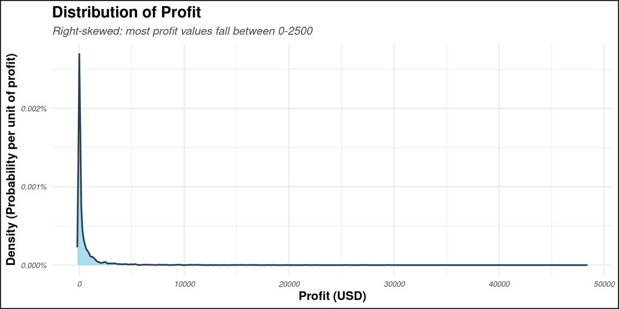

# Montary Features

- rev_per_unit (Revenue per unit)
- rev_to_cost (Revenue to cost ratio)
- price_tier (Retail price tiers)
  - low, medium, high, premium
- cost_per_pound (Cost to produce per lbs)
- component_price_combo (number of components * by price)
- cost_to_price (Cost to price ratio)

# Non-Monetary Features

- is_aluminum_material (Flags products made from aluminum)
- high_range_and_common (Flags products with high range of applicable years & is common/make and model)
- is_lathe_mfg (Products manufactured with a lathe)
- pct_mobile_source (Percentage of sales made from mobile purchases)

# Results

- Best RMSE: 410.36
- Lnear Model RMSE: 1726.336 vs XGBoost RMSE: 410.36
  - Applied the Inverse Hyperbolic Sine (IHS) transformation
  - We chose the XGBoost model because of its ability to capture complex interactions, and built-in regularization to prevent overfitting.

# Insights & Conclusion

- While an RMSE of 410.36 is sufficient when predicting values between -180.53 48424.57. However, when considering that most values fall between 0 & 2,500 the model becomes less effective.

# Thank You

*Questions?*